# Optimal Treatment Analysis

## Outcome Variable

**Outcome Variable:** ever_stunted

## Predictor Variables

**Intervention Variable:** parity

**Adjustment Set:**

- arm
- W_mage
- meducyrs
- feducyrs
- hhwealth_quart
- W_mhtcm
- vagbrth
- W_nrooms
- impfloor
- impsan
- safeh20
- delta_W_mage
- delta_meducyrs
- delta_feducyrs
- delta_hhwealth_quart
- delta_W_mhtcm
- delta_vagbrth
- delta_W_nrooms
- delta_impfloor
- delta_impsan
- delta_safeh20

## Stratifying Variables

The analysis was stratified on these variable(s):

- agecat
- studyid
- country

## Data Summary

| agecat | studyid | country | parity | ever_stunted | n_cell | n |
| --- | --- | --- | --- | --- | --- | --- |
| 0-24 months | ki1000304b-SAS-CompFeed | INDIA | 1 | 0 | 162 | 1533 |
| 0-24 months | ki1000304b-SAS-CompFeed | INDIA | 1 | 1 | 290 | 1533 |
| 0-24 months | ki1000304b-SAS-CompFeed | INDIA | 2 | 0 | 122 | 1533 |
| 0-24 months | ki1000304b-SAS-CompFeed | INDIA | 2 | 1 | 238 | 1533 |
| 0-24 months | ki1000304b-SAS-CompFeed | INDIA | 3+ | 0 | 189 | 1533 |
| 0-24 months | ki1000304b-SAS-CompFeed | INDIA | 3+ | 1 | 532 | 1533 |
| 0-24 months | ki1000304b-SAS-FoodSuppl | INDIA | 1 | 0 | 19 | 397 |
| 0-24 months | ki1000304b-SAS-FoodSuppl | INDIA | 1 | 1 | 58 | 397 |
| 0-24 months | ki1000304b-SAS-FoodSuppl | INDIA | 2 | 0 | 12 | 397 |
| 0-24 months | ki1000304b-SAS-FoodSuppl | INDIA | 2 | 1 | 80 | 397 |
| 0-24 months | ki1000304b-SAS-FoodSuppl | INDIA | 3+ | 0 | 28 | 397 |
| 0-24 months | ki1000304b-SAS-FoodSuppl | INDIA | 3+ | 1 | 200 | 397 |
| 0-24 months | ki1017093b-PROVIDE | BANGLADESH | 1 | 0 | 154 | 700 |
| 0-24 months | ki1017093b-PROVIDE | BANGLADESH | 1 | 1 | 117 | 700 |
| 0-24 months | ki1017093b-PROVIDE | BANGLADESH | 2 | 0 | 134 | 700 |
| 0-24 months | ki1017093b-PROVIDE | BANGLADESH | 2 | 1 | 110 | 700 |
| 0-24 months | ki1017093b-PROVIDE | BANGLADESH | 3+ | 0 | 108 | 700 |
| 0-24 months | ki1017093b-PROVIDE | BANGLADESH | 3+ | 1 | 77 | 700 |
| 0-24 months | ki1066203-TanzaniaChild2 | TANZANIA, UNITED REPUBLIC OF | 1 | 0 | 550 | 2357 |
| 0-24 months | ki1066203-TanzaniaChild2 | TANZANIA, UNITED REPUBLIC OF | 1 | 1 | 271 | 2357 |
| 0-24 months | ki1066203-TanzaniaChild2 | TANZANIA, UNITED REPUBLIC OF | 2 | 0 | 494 | 2357 |
| 0-24 months | ki1066203-TanzaniaChild2 | TANZANIA, UNITED REPUBLIC OF | 2 | 1 | 277 | 2357 |
| 0-24 months | ki1066203-TanzaniaChild2 | TANZANIA, UNITED REPUBLIC OF | 3+ | 0 | 495 | 2357 |
| 0-24 months | ki1066203-TanzaniaChild2 | TANZANIA, UNITED REPUBLIC OF | 3+ | 1 | 270 | 2357 |
| 0-24 months | ki1101329-Keneba | GAMBIA | 1 | 0 | 119 | 1990 |
| 0-24 months | ki1101329-Keneba | GAMBIA | 1 | 1 | 122 | 1990 |
| 0-24 months | ki1101329-Keneba | GAMBIA | 2 | 0 | 110 | 1990 |
| 0-24 months | ki1101329-Keneba | GAMBIA | 2 | 1 | 104 | 1990 |
| 0-24 months | ki1101329-Keneba | GAMBIA | 3+ | 0 | 632 | 1990 |
| 0-24 months | ki1101329-Keneba | GAMBIA | 3+ | 1 | 903 | 1990 |

[output cut: 168 more lines]

The following strata were considered:

- agecat: 0-24 months, studyid: ki1000304b-SAS-CompFeed, country: INDIA
- agecat: 0-24 months, studyid: ki1000304b-SAS-FoodSuppl, country: INDIA
- agecat: 0-24 months, studyid: ki1017093b-PROVIDE, country: BANGLADESH
- agecat: 0-24 months, studyid: ki1066203-TanzaniaChild2, country: TANZANIA, UNITED REPUBLIC OF
- agecat: 0-24 months, studyid: ki1101329-Keneba, country: GAMBIA
- agecat: 0-24 months, studyid: ki1113344-GMS-Nepal, country: NEPAL
- agecat: 0-24 months, studyid: ki1126311-ZVITAMBO, country: ZIMBABWE
- agecat: 0-24 months, studyid: ki1135781-COHORTS, country: GUATEMALA
- agecat: 0-24 months, studyid: ki1135781-COHORTS, country: INDIA
- agecat: 0-24 months, studyid: ki1135781-COHORTS, country: PHILIPPINES
- agecat: 0-24 months, studyid: kiGH5241-JiVitA-3, country: BANGLADESH
- agecat: 0-6 months, studyid: ki1000304b-SAS-CompFeed, country: INDIA
- agecat: 0-6 months, studyid: ki1000304b-SAS-FoodSuppl, country: INDIA
- agecat: 0-6 months, studyid: ki1017093b-PROVIDE, country: BANGLADESH
- agecat: 0-6 months, studyid: ki1066203-TanzaniaChild2, country: TANZANIA, UNITED REPUBLIC OF
- agecat: 0-6 months, studyid: ki1101329-Keneba, country: GAMBIA
- agecat: 0-6 months, studyid: ki1113344-GMS-Nepal, country: NEPAL
- agecat: 0-6 months, studyid: ki1126311-ZVITAMBO, country: ZIMBABWE
- agecat: 0-6 months, studyid: ki1135781-COHORTS, country: GUATEMALA
- agecat: 0-6 months, studyid: ki1135781-COHORTS, country: INDIA
- agecat: 0-6 months, studyid: ki1135781-COHORTS, country: PHILIPPINES
- agecat: 0-6 months, studyid: kiGH5241-JiVitA-3, country: BANGLADESH
- agecat: 6-24 months, studyid: ki1000304b-SAS-CompFeed, country: INDIA
- agecat: 6-24 months, studyid: ki1000304b-SAS-FoodSuppl, country: INDIA
- agecat: 6-24 months, studyid: ki1017093b-PROVIDE, country: BANGLADESH
- agecat: 6-24 months, studyid: ki1066203-TanzaniaChild2, country: TANZANIA, UNITED REPUBLIC OF
- agecat: 6-24 months, studyid: ki1101329-Keneba, country: GAMBIA
- agecat: 6-24 months, studyid: ki1113344-GMS-Nepal, country: NEPAL
- agecat: 6-24 months, studyid: ki1126311-ZVITAMBO, country: ZIMBABWE
- agecat: 6-24 months, studyid: ki1135781-COHORTS, country: GUATEMALA
- agecat: 6-24 months, studyid: ki1135781-COHORTS, country: INDIA
- agecat: 6-24 months, studyid: ki1135781-COHORTS, country: PHILIPPINES
- agecat: 6-24 months, studyid: kiGH5241-JiVitA-3, country: BANGLADESH

## Methods Detail

We’re interested in the causal parameters $E[Y_a]$ for all values of $a \in \mathcal{A}$. These parameters represent the mean outcome if, possibly contrary to fact, we intervened to set all units to have $A=a$. Under the randomization and positivity assumptions, these are identified by the statistical parameters $\psi_a=E_W[E_{Y|A,W}(Y|A=a,W)]$. In addition, we’re interested in the mean of $Y$, $E[Y]$ under no intervention (the observed mean). We will estimate these parameters by using SuperLearner to fit the relevant likelihood factors – $E_{Y|A,W}(Y|A=a,W)$ and $p(A=a|W)$, and then updating our likelihood fit using a joint TMLE.

For unadjusted analyses ($W=\{\}$), initial likelihoods were estimated using Lrnr_glm to estimate the simple $E(Y|A)$ and Lrnr_mean to estimate $p(A)$. For adjusted analyses, a small library containing Lrnr_glmnet, Lrnr_xgboost, and Lrnr_mean was used.

Having estimated these parameters, we will then use the delta method to estimate relative risks and attributable risks relative to a prespecified baseline level of $A$.

# Results Detail

## Results Plots

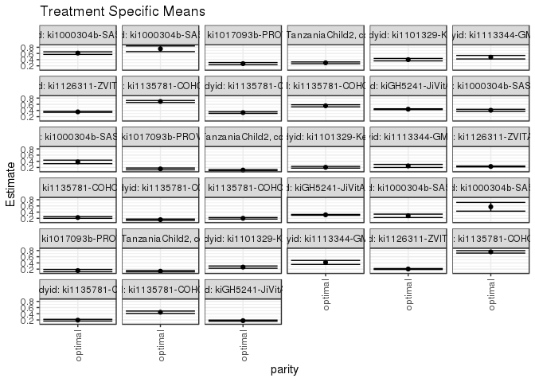

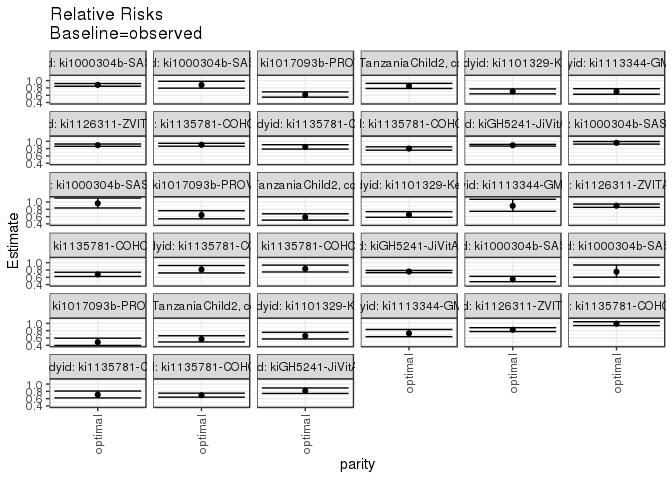

## Results Table

### Parameter: TSM

| agecat | studyid | country | intervention_level | baseline_level | estimate | ci_lower | ci_upper |
| --- | --- | --- | --- | --- | --- | --- | --- |
| 0-24 months | ki1000304b-SAS-CompFeed | INDIA | optimal | NA | 0.6110673 | 0.5694150 | 0.6527197 |
| 0-24 months | ki1000304b-SAS-FoodSuppl | INDIA | optimal | NA | 0.7500907 | 0.6579390 | 0.8422425 |
| 0-24 months | ki1017093b-PROVIDE | BANGLADESH | optimal | NA | 0.2707555 | 0.2350907 | 0.3064202 |
| 0-24 months | ki1066203-TanzaniaChild2 | TANZANIA, UNITED REPUBLIC OF | optimal | NA | 0.2972634 | 0.2688737 | 0.3256531 |
| 0-24 months | ki1101329-Keneba | GAMBIA | optimal | NA | 0.3996569 | 0.3603361 | 0.4389778 |
| 0-24 months | ki1113344-GMS-Nepal | NEPAL | optimal | NA | 0.4790104 | 0.4211957 | 0.5368252 |
| 0-24 months | ki1126311-ZVITAMBO | ZIMBABWE | optimal | NA | 0.3547923 | 0.3405001 | 0.3690845 |
| 0-24 months | ki1135781-COHORTS | GUATEMALA | optimal | NA | 0.6907685 | 0.6582494 | 0.7232875 |
| 0-24 months | ki1135781-COHORTS | INDIA | optimal | NA | 0.3306218 | 0.3044239 | 0.3568196 |
| 0-24 months | ki1135781-COHORTS | PHILIPPINES | optimal | NA | 0.5500986 | 0.5158824 | 0.5843147 |
| 0-24 months | kiGH5241-JiVitA-3 | BANGLADESH | optimal | NA | 0.4406907 | 0.4274534 | 0.4539281 |
| 0-6 months | ki1000304b-SAS-CompFeed | INDIA | optimal | NA | 0.4058578 | 0.3726692 | 0.4390463 |
| 0-6 months | ki1000304b-SAS-FoodSuppl | INDIA | optimal | NA | 0.3798140 | 0.3232978 | 0.4363303 |
| 0-6 months | ki1017093b-PROVIDE | BANGLADESH | optimal | NA | 0.1537616 | 0.1248487 | 0.1826746 |
| 0-6 months | ki1066203-TanzaniaChild2 | TANZANIA, UNITED REPUBLIC OF | optimal | NA | 0.1159636 | 0.0968950 | 0.1350322 |
| 0-6 months | ki1101329-Keneba | GAMBIA | optimal | NA | 0.2067310 | 0.1794017 | 0.2340602 |
| 0-6 months | ki1113344-GMS-Nepal | NEPAL | optimal | NA | 0.2490692 | 0.1993863 | 0.2987521 |
| 0-6 months | ki1126311-ZVITAMBO | ZIMBABWE | optimal | NA | 0.2322230 | 0.2192316 | 0.2452145 |
| 0-6 months | ki1135781-COHORTS | GUATEMALA | optimal | NA | 0.2249352 | 0.1982461 | 0.2516243 |
| 0-6 months | ki1135781-COHORTS | INDIA | optimal | NA | 0.1549398 | 0.1338774 | 0.1760023 |
| 0-6 months | ki1135781-COHORTS | PHILIPPINES | optimal | NA | 0.2004323 | 0.1757884 | 0.2250762 |
| 0-6 months | kiGH5241-JiVitA-3 | BANGLADESH | optimal | NA | 0.3114634 | 0.2981414 | 0.3247853 |
| 6-24 months | ki1000304b-SAS-CompFeed | INDIA | optimal | NA | 0.2800649 | 0.2257144 | 0.3344154 |
| 6-24 months | ki1000304b-SAS-FoodSuppl | INDIA | optimal | NA | 0.5717076 | 0.4307261 | 0.7126891 |
| 6-24 months | ki1017093b-PROVIDE | BANGLADESH | optimal | NA | 0.1518803 | 0.1150172 | 0.1887434 |
| 6-24 months | ki1066203-TanzaniaChild2 | TANZANIA, UNITED REPUBLIC OF | optimal | NA | 0.1323313 | 0.1099111 | 0.1547515 |
| 6-24 months | ki1101329-Keneba | GAMBIA | optimal | NA | 0.2643165 | 0.2280399 | 0.3005931 |
| 6-24 months | ki1113344-GMS-Nepal | NEPAL | optimal | NA | 0.4160649 | 0.3508746 | 0.4812553 |
| 6-24 months | ki1126311-ZVITAMBO | ZIMBABWE | optimal | NA | 0.2033982 | 0.1885208 | 0.2182755 |
| 6-24 months | ki1135781-COHORTS | GUATEMALA | optimal | NA | 0.7572391 | 0.7180196 | 0.7964586 |
| 6-24 months | ki1135781-COHORTS | INDIA | optimal | NA | 0.1927136 | 0.1654448 | 0.2199823 |
| 6-24 months | ki1135781-COHORTS | PHILIPPINES | optimal | NA | 0.4484873 | 0.4103279 | 0.4866467 |
| 6-24 months | kiGH5241-JiVitA-3 | BANGLADESH | optimal | NA | 0.1769661 | 0.1594714 | 0.1944608 |

### Parameter: E(Y)

| agecat | studyid | country | intervention_level | baseline_level | estimate | ci_lower | ci_upper |
| --- | --- | --- | --- | --- | --- | --- | --- |
| 0-24 months | ki1000304b-SAS-CompFeed | INDIA | observed | NA | 0.6919189 | 0.6515151 | 0.7323227 |
| 0-24 months | ki1000304b-SAS-FoodSuppl | INDIA | observed | NA | 0.8510588 | 0.8160244 | 0.8860932 |
| 0-24 months | ki1017093b-PROVIDE | BANGLADESH | observed | NA | 0.4404704 | 0.4037256 | 0.4772152 |
| 0-24 months | ki1066203-TanzaniaChild2 | TANZANIA, UNITED REPUBLIC OF | observed | NA | 0.3488641 | 0.3296422 | 0.3680860 |
| 0-24 months | ki1101329-Keneba | GAMBIA | observed | NA | 0.5689736 | 0.5472002 | 0.5907470 |
| 0-24 months | ki1113344-GMS-Nepal | NEPAL | observed | NA | 0.6851180 | 0.6476548 | 0.7225813 |
| 0-24 months | ki1126311-ZVITAMBO | ZIMBABWE | observed | NA | 0.3968973 | 0.3888144 | 0.4049801 |
| 0-24 months | ki1135781-COHORTS | GUATEMALA | observed | NA | 0.7641167 | 0.7415400 | 0.7866933 |
| 0-24 months | ki1135781-COHORTS | INDIA | observed | NA | 0.3913165 | 0.3772583 | 0.4053747 |
| 0-24 months | ki1135781-COHORTS | PHILIPPINES | observed | NA | 0.6865654 | 0.6701188 | 0.7030121 |
| 0-24 months | kiGH5241-JiVitA-3 | BANGLADESH | observed | NA | 0.4942811 | 0.4864345 | 0.5021276 |
| 0-6 months | ki1000304b-SAS-CompFeed | INDIA | observed | NA | 0.4237413 | 0.3959713 | 0.4515112 |
| 0-6 months | ki1000304b-SAS-FoodSuppl | INDIA | observed | NA | 0.3942500 | 0.3460638 | 0.4424361 |
| 0-6 months | ki1017093b-PROVIDE | BANGLADESH | observed | NA | 0.2399380 | 0.2083419 | 0.2715341 |
| 0-6 months | ki1066203-TanzaniaChild2 | TANZANIA, UNITED REPUBLIC OF | observed | NA | 0.1987920 | 0.1828018 | 0.2147823 |
| 0-6 months | ki1101329-Keneba | GAMBIA | observed | NA | 0.3161697 | 0.2950405 | 0.3372989 |
| 0-6 months | ki1113344-GMS-Nepal | NEPAL | observed | NA | 0.2785896 | 0.2427950 | 0.3143842 |
| 0-6 months | ki1126311-ZVITAMBO | ZIMBABWE | observed | NA | 0.2586168 | 0.2513817 | 0.2658518 |
| 0-6 months | ki1135781-COHORTS | GUATEMALA | observed | NA | 0.3315595 | 0.3037455 | 0.3593735 |
| 0-6 months | ki1135781-COHORTS | INDIA | observed | NA | 0.1902299 | 0.1787262 | 0.2017336 |
| 0-6 months | ki1135781-COHORTS | PHILIPPINES | observed | NA | 0.2402721 | 0.2251532 | 0.2553909 |
| 0-6 months | kiGH5241-JiVitA-3 | BANGLADESH | observed | NA | 0.4113213 | 0.4038730 | 0.4187697 |
| 6-24 months | ki1000304b-SAS-CompFeed | INDIA | observed | NA | 0.5107961 | 0.4665702 | 0.5550220 |
| 6-24 months | ki1000304b-SAS-FoodSuppl | INDIA | observed | NA | 0.7603318 | 0.7061898 | 0.8144739 |
| 6-24 months | ki1017093b-PROVIDE | BANGLADESH | observed | NA | 0.3132596 | 0.2712078 | 0.3553114 |
| 6-24 months | ki1066203-TanzaniaChild2 | TANZANIA, UNITED REPUBLIC OF | observed | NA | 0.2323552 | 0.2116533 | 0.2530570 |
| 6-24 months | ki1101329-Keneba | GAMBIA | observed | NA | 0.4022376 | 0.3762235 | 0.4282518 |
| 6-24 months | ki1113344-GMS-Nepal | NEPAL | observed | NA | 0.5715924 | 0.5244117 | 0.6187730 |
| 6-24 months | ki1126311-ZVITAMBO | ZIMBABWE | observed | NA | 0.2461049 | 0.2366427 | 0.2555672 |
| 6-24 months | ki1135781-COHORTS | GUATEMALA | observed | NA | 0.7640865 | 0.7362621 | 0.7919109 |
| 6-24 months | ki1135781-COHORTS | INDIA | observed | NA | 0.2716921 | 0.2570720 | 0.2863123 |
| 6-24 months | ki1135781-COHORTS | PHILIPPINES | observed | NA | 0.6463470 | 0.6259775 | 0.6667165 |
| 6-24 months | kiGH5241-JiVitA-3 | BANGLADESH | observed | NA | 0.2171538 | 0.2077960 | 0.2265116 |

### Parameter: RR

| agecat | studyid | country | intervention_level | baseline_level | estimate | ci_lower | ci_upper |
| --- | --- | --- | --- | --- | --- | --- | --- |
| 0-24 months | ki1000304b-SAS-CompFeed | INDIA | optimal | observed | 0.8831488 | 0.8465986 | 0.9212770 |
| 0-24 months | ki1000304b-SAS-FoodSuppl | INDIA | optimal | observed | 0.8813619 | 0.7923524 | 0.9803703 |
| 0-24 months | ki1017093b-PROVIDE | BANGLADESH | optimal | observed | 0.6146962 | 0.5474619 | 0.6901876 |
| 0-24 months | ki1066203-TanzaniaChild2 | TANZANIA, UNITED REPUBLIC OF | optimal | observed | 0.8520893 | 0.7847079 | 0.9252567 |
| 0-24 months | ki1101329-Keneba | GAMBIA | optimal | observed | 0.7024174 | 0.6383332 | 0.7729351 |
| 0-24 months | ki1113344-GMS-Nepal | NEPAL | optimal | observed | 0.6991648 | 0.6277275 | 0.7787320 |
| 0-24 months | ki1126311-ZVITAMBO | ZIMBABWE | optimal | observed | 0.8939146 | 0.8629641 | 0.9259751 |
| 0-24 months | ki1135781-COHORTS | GUATEMALA | optimal | observed | 0.9040091 | 0.8651686 | 0.9445934 |
| 0-24 months | ki1135781-COHORTS | INDIA | optimal | observed | 0.8448961 | 0.7868911 | 0.9071767 |
| 0-24 months | ki1135781-COHORTS | PHILIPPINES | optimal | observed | 0.8012325 | 0.7567002 | 0.8483856 |
| 0-24 months | kiGH5241-JiVitA-3 | BANGLADESH | optimal | observed | 0.8915792 | 0.8684619 | 0.9153119 |
| 0-6 months | ki1000304b-SAS-CompFeed | INDIA | optimal | observed | 0.9577962 | 0.9230866 | 0.9938109 |
| 0-6 months | ki1000304b-SAS-FoodSuppl | INDIA | optimal | observed | 0.9633838 | 0.8366770 | 1.1092791 |
| 0-6 months | ki1017093b-PROVIDE | BANGLADESH | optimal | observed | 0.6408392 | 0.5392618 | 0.7615499 |
| 0-6 months | ki1066203-TanzaniaChild2 | TANZANIA, UNITED REPUBLIC OF | optimal | observed | 0.5833414 | 0.5030318 | 0.6764726 |
| 0-6 months | ki1101329-Keneba | GAMBIA | optimal | observed | 0.6538608 | 0.5806474 | 0.7363056 |
| 0-6 months | ki1113344-GMS-Nepal | NEPAL | optimal | observed | 0.8940363 | 0.7447924 | 1.0731861 |
| 0-6 months | ki1126311-ZVITAMBO | ZIMBABWE | optimal | observed | 0.8979428 | 0.8551191 | 0.9429111 |
| 0-6 months | ki1135781-COHORTS | GUATEMALA | optimal | observed | 0.6784158 | 0.6228705 | 0.7389144 |
| 0-6 months | ki1135781-COHORTS | INDIA | optimal | observed | 0.8144871 | 0.7193363 | 0.9222241 |
| 0-6 months | ki1135781-COHORTS | PHILIPPINES | optimal | observed | 0.8341888 | 0.7452052 | 0.9337978 |
| 0-6 months | kiGH5241-JiVitA-3 | BANGLADESH | optimal | observed | 0.7572264 | 0.7282827 | 0.7873203 |
| 6-24 months | ki1000304b-SAS-CompFeed | INDIA | optimal | observed | 0.5482910 | 0.4796855 | 0.6267086 |
| 6-24 months | ki1000304b-SAS-FoodSuppl | INDIA | optimal | observed | 0.7519185 | 0.6038238 | 0.9363352 |
| 6-24 months | ki1017093b-PROVIDE | BANGLADESH | optimal | observed | 0.4848384 | 0.3949590 | 0.5951713 |
| 6-24 months | ki1066203-TanzaniaChild2 | TANZANIA, UNITED REPUBLIC OF | optimal | observed | 0.5695218 | 0.4908275 | 0.6608331 |
| 6-24 months | ki1101329-Keneba | GAMBIA | optimal | observed | 0.6571153 | 0.5723668 | 0.7544124 |
| 6-24 months | ki1113344-GMS-Nepal | NEPAL | optimal | observed | 0.7279050 | 0.6357264 | 0.8334492 |
| 6-24 months | ki1126311-ZVITAMBO | ZIMBABWE | optimal | observed | 0.8264692 | 0.7751256 | 0.8812139 |
| 6-24 months | ki1135781-COHORTS | GUATEMALA | optimal | observed | 0.9910384 | 0.9400991 | 1.0447378 |
| 6-24 months | ki1135781-COHORTS | INDIA | optimal | observed | 0.7093086 | 0.6214911 | 0.8095349 |
| 6-24 months | ki1135781-COHORTS | PHILIPPINES | optimal | observed | 0.6938801 | 0.6415469 | 0.7504823 |
| 6-24 months | kiGH5241-JiVitA-3 | BANGLADESH | optimal | observed | 0.8149343 | 0.7431828 | 0.8936131 |